# Praca domowa 2

Karolina Nieciecka

## Dane

Dane wykorzystane w Pracy domowej 2 dotyczą wyników egzaminów z 3 umiejętności: czytania, pisania i operacji matematycznych. Dodatkowo dostępne są podstawowe informacje o studentach i ich rodzicach. Opis wszystkich kolumn znajduje się również w pliku `README.md`.

| Zmienna | Opis |
| --- | --- |
| **gender** | płeć |
| **race.ethnicity** | pochodzenie etniczne |
| **parental.level.of.education** | wykształcenie rodziców |
| **lunch** | jaki obiad jedli uczniowie w dniu egzaminu |
| **test.preparation.course** | czy uczeń odbył kurs przygotowujący |
| **math.score** | wynik egzaminu z matematyki |
| **reading.score** | wynik egzaminu z czytania |
| **writing.score** | wynik egzaminu z pisania |

## Zadanie 1

Jak wyglądają rozkłady wyników uczniów z trzech przedmiotów (matematyka, czytanie, pisanie)?

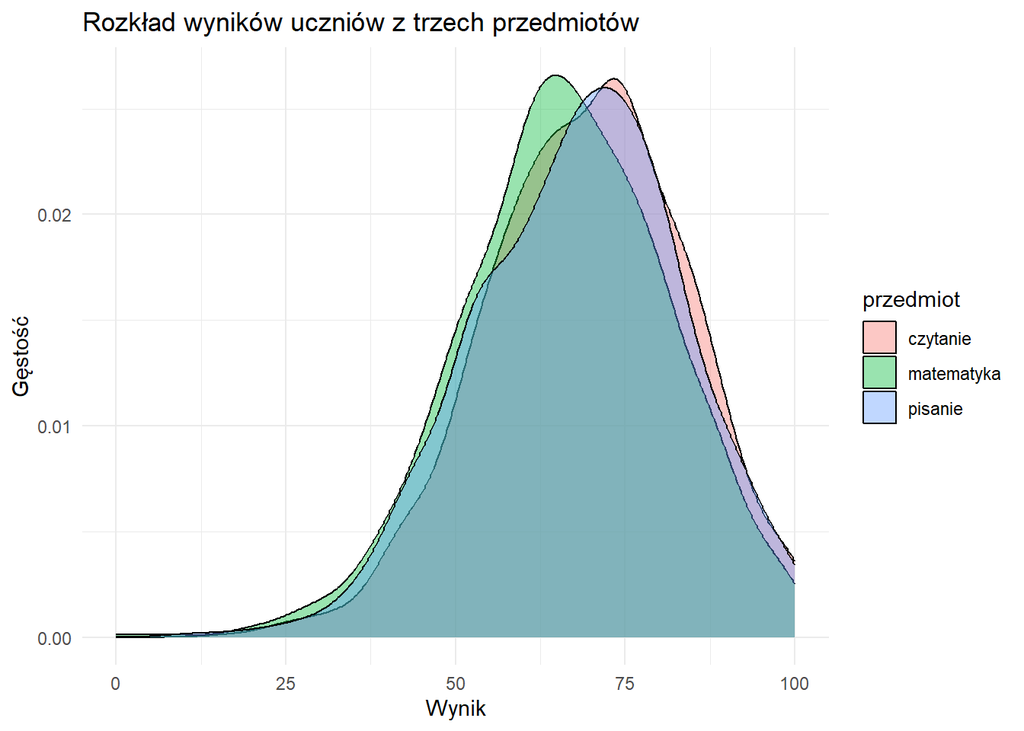

```r
df1 <- select(df, math.score, reading.score, writing.score)
colnames(df1) <- c('matematyka', 'czytanie','pisanie' )
df1 <- df1 %>%
  pivot_longer(cols = c(matematyka, czytanie, pisanie),
               names_to = 'przedmiot',
               values_to = 'wynik')
ggplot(df1, aes(x=wynik, fill=przedmiot))+
  geom_density(alpha = 0.4)+
  theme_minimal()+
  labs(title = 'Rozkład wyników uczniów z trzech przedmiotów',
       x = 'Wynik',
       y = 'Gęstość')
```

**Komentarz:** Na wykresie gęstości wyników widać, że większość uczniów uzyskała wyniki powyżej 50% ze wszystkich trzech przedmiotów, natomiast bardzo rzadko pojawiały się wyniki poniżej 25%. Rozkład wyników z matematyki są delikatnie przesunięte w stronę niższych wartości, a wyniki z czytania i pisania mają bardzo podobny rozkład.

## Zadanie 2

Czy istnieje zauważalna różnica w wynikach między uczniami i uczennicami?

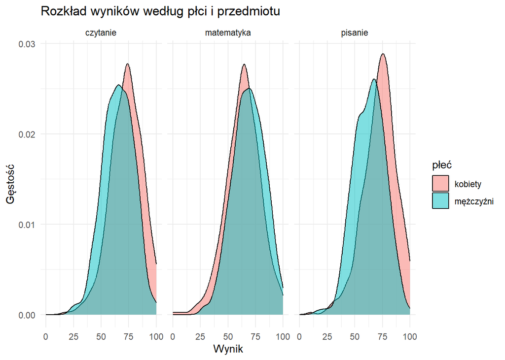

```r
df2 <- select(df, gender,math.score, reading.score, writing.score)
colnames(df2) <- c('płeć', 'matematyka', 'czytanie','pisanie' )
df2 <- df2 %>%
  mutate(płeć = recode(płeć, 'female' = 'kobiety', 'male' = 'mężczyźni'))
df2 <- df2 %>%
  pivot_longer(cols = c(matematyka, czytanie, pisanie),
               names_to = 'przedmiot',
               values_to = 'wynik')
ggplot(df2, aes(x = wynik, fill = płeć))+
  geom_density(alpha = 0.5)+
  facet_wrap(~przedmiot)+
  theme_minimal()+
  labs(title = 'Rozkład wyników według płci i przedmiotu',
       x = 'Wynik', y = 'Gęstość')
```

## Zadanie 3

Czy uczniowie, którzy ukończyli kurs przygotowawczy, osiągają lepsze wyniki niż pozostali?

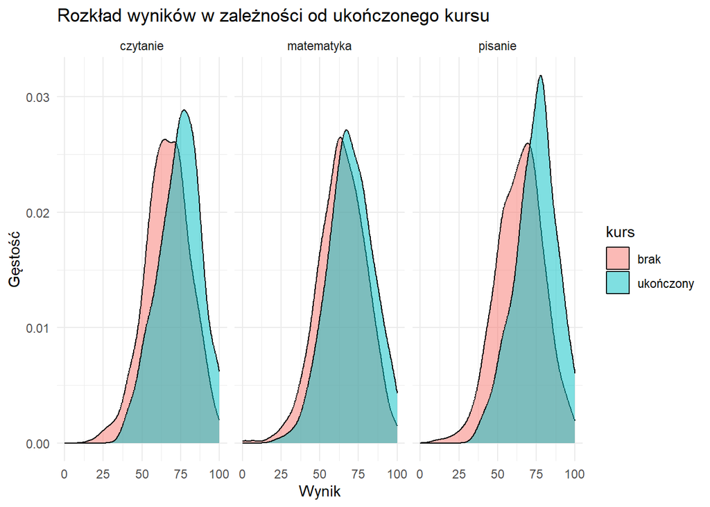

```r
df3 <- select(df,math.score, reading.score, writing.score, test.preparation.course)
colnames(df3) <- c('matematyka', 'czytanie','pisanie', 'kurs' )
df3 <- df3 %>%
  mutate(kurs = recode(kurs, 'completed' = 'ukończony', 'none' = 'brak'))
df3 <- df3 %>%
  pivot_longer(cols = c(matematyka, czytanie, pisanie),
               names_to = 'przedmiot',
               values_to = 'wynik')
ggplot(df3, aes(x = wynik, fill = kurs))+
  geom_density(alpha = 0.5)+
  facet_wrap(~przedmiot)+
  theme_minimal()+
  labs(title = 'Rozkład wyników w zależności od ukończonego kursu',
       x = 'Wynik', y = 'Gęstość')
```

Jaki jest związek między poziomem wykształcenia rodziców a średnimi wynikami uczniów?

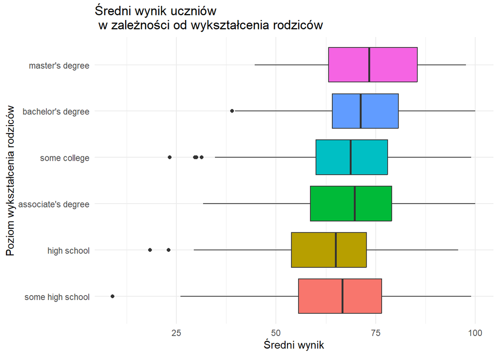

```r
df4 <- df %>%
  select(parental.level.of.education, math.score, reading.score, writing.score) %>%
  mutate(średni_wynik = (math.score + reading.score + writing.score)/3) %>%
  mutate(parental.level.of.education = fct_relevel(parental.level.of.education, "some high school", "high school", "associate's degree", "some college", "bachelor's degree","master's degree" ))
ggplot(df4, aes(x=średni_wynik, y=parental.level.of.education, fill = parental.level.of.education))+
  geom_boxplot()+
  theme_minimal()+
  theme(legend.position = 'none')+
  labs(title = 'Średni wynik uczniów \n w zależności od wykształcenia rodziców',
       x = 'Średni wynik',
       y = 'Poziom wykształcenia rodziców')
```

**Komentarz:** Widać tendencję, że wraz ze wzrostem poziomu wykształcenia rodziców rosną średnie wyniki uczniów. Najwyższe wyniki uzyskali uczniowie, których rodzice mają ukończone studia magisterskie (master’s degree), najniższe - ci, których rodzice ukończyli jedynie szkołę średnią (high school).

## Zadanie 5

Czy płeć i wykształcenie rodzica wpływa na wynik z matematyki?

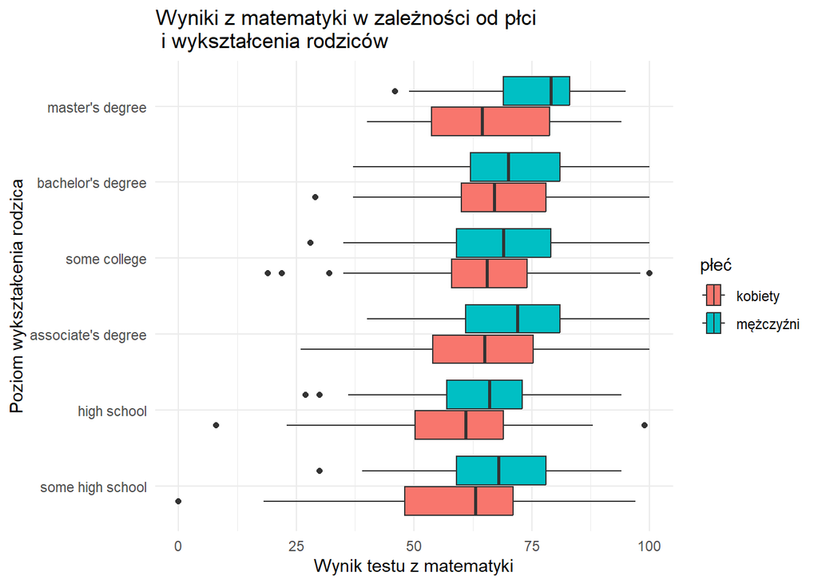

```r
df5 <- df %>%
  select(gender, parental.level.of.education, math.score)
colnames(df5) <- c('płeć', 'poziom_wykształcenia_rodzica', 'wynik_matematyka')
df5 <- df5 %>%
  mutate(płeć = recode(płeć, 'female' = 'kobiety', 'male' = 'mężczyźni')) %>%
  mutate(poziom_wykształcenia_rodzica = fct_relevel(poziom_wykształcenia_rodzica, "some high school", "high school", "associate's degree", "some college", "bachelor's degree","master's degree" ))
ggplot(df5, aes(y = poziom_wykształcenia_rodzica, x = wynik_matematyka, fill = płeć))+
  geom_boxplot(position = position_dodge(0.8))+
  theme_minimal()+
  labs(title = "Wyniki z matematyki w zależności od płci \n i wykształcenia rodziców",
       x = "Wynik testu z matematyki",
       y = "Poziom wykształcenia rodzica")
```

**Komentarz:** Ogólnie najlepsze wyniki uzyskali mężczyźni a w szczególności ci, których rodzice mieli ukończone studia magisterskie. Najgorzej poradziły sobie kobiety, których rodzice skończyli szkołę średnią (high school, some high school).

## Zadanie 6

Czy istnieje zależność między wynikami z matematyki a wynikami z czytania lub pisania?

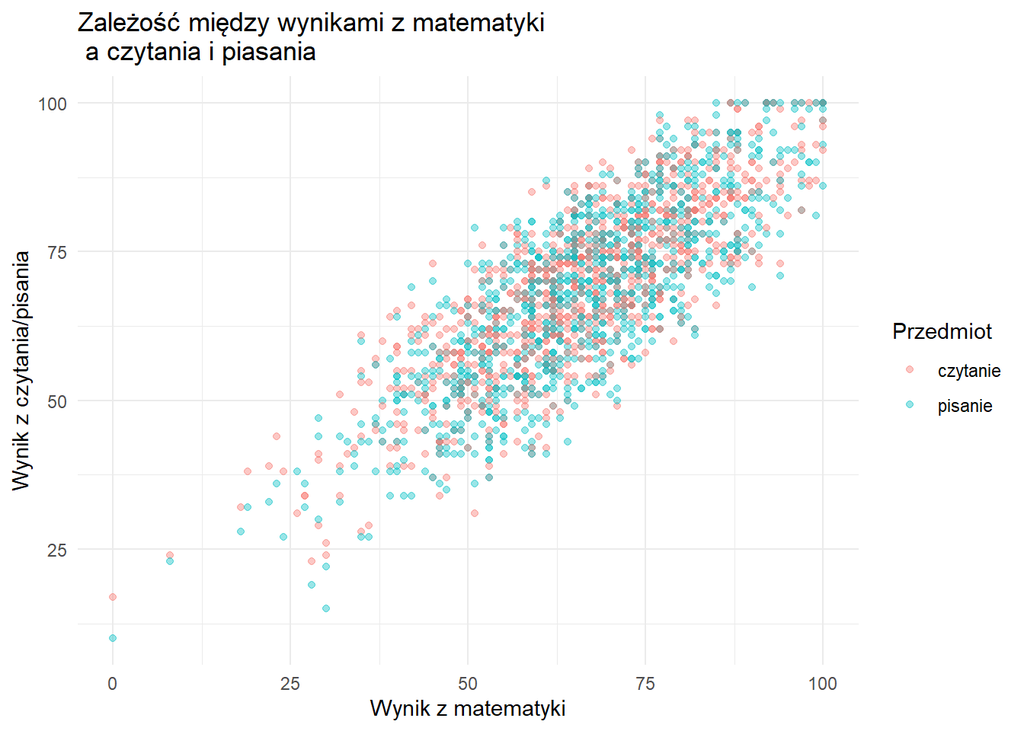

```r
df6 <-  df %>%
  select(math.score, reading.score, writing.score) %>%
  pivot_longer(cols= c(reading.score, writing.score),
               names_to = 'przedmiot', values_to = 'wynik') %>%
  mutate(przedmiot = recode(przedmiot, 'reading.score' = 'czytanie', 'writing.score' = 'pisanie'))
ggplot(df6, aes(x=math.score, y=wynik, color = przedmiot))+
  geom_point(alpha = 0.4)+
  theme_minimal()+
  labs(title= 'Zależość między wynikami z matematyki \n a czytania i piasania',
       x = 'Wynik z matematyki',
       y = 'Wynik z czytania/pisania',
       color = 'Przedmiot')
```

**Komentarz:** Widać wyraźną zależność - uczniowe mający wyższe wyniki z matematyki uzyskują wyższe wyniki z czytania i pisania.